# Taller 2: ¿son distintos estos grupos? El informe para su cliente

Gerencia de Riesgo de Crédito · Hotelling de una y de dos muestras

Oscar Manuel Contreras Gacha (20221020052)

Juan Pablo Sarmiento Ramírez (20221020138)

Steven Navarro Parrales (20221020048)

Juan Diego Grajales Castillo (20221020128)

Estadística Multidimensional · 26158 · grupo 020-81 · periodo 2026-3

Cada resultado se lee con tres frases, como en las notas:

- 👀 **Qué vemos**: el número o el gráfico, sin interpretar.
- 💼 **Qué significa para el cliente**: la traducción a la cartera de tarjetas.
- ✅ **Qué decide el cliente**: la consecuencia práctica.

Y el informe responde siempre **tres preguntas** por comparación: **¿es real?** (¿puede ser azar?), **¿es grande?** (¿a cuántas desviaciones?) y **¿separa?** (si me dan a un cliente, ¿sé de qué grupo es?).

# 1 El encargo

**El cliente es la Gerencia de Riesgo de Crédito del banco emisor** de las tarjetas de la base (rupias indias, ₹), el mismo de los talleres anteriores. Para el comité de riesgos de fin de año nos escribe:

> «Vamos a presentar la segmentación de la cartera y necesitamos saber dos cosas. **Primera:** nuestros clientes de gama alta (tarjetas Platinum y Signature), ¿se comportan distinto del resto de la cartera? Si sí, les armamos una política propia de seguimiento y de aumentos de cupo; si no, les basta la política general. **Segunda:** vamos a diseñar campañas de seguimiento preventivo y de educación financiera por grupo de edad. ¿Los clientes jóvenes y los mayores llegan con perfiles distintos, o da igual?»

Son las dos preguntas del taller, con una comparación cada una:

- **Una muestra:** el grupo de **gama alta** (Platinum y Signature) frente a **la referencia: el promedio de toda la cartera**. La referencia sale de esta misma base (50 000 clientes sintéticos), no de una meta del banco ni de una cifra publicada, y el informe lo dice así; además el grupo hace parte de la referencia, igual que el Atlántico hacía parte del país en las notas.
- **Dos muestras:** los **clientes jóvenes** frente a los **mayores** (el tercio más joven y el tercio más viejo de la base por edad; el tercio de en medio queda por fuera para que la comparación sea entre dos grupos claramente distintos en edad).

Ninguno de los dos grupos se define con las variables que se comparan: la gama alta se define con el **tipo de tarjeta** y los grupos de edad con la **edad**, y ninguna de las dos entra entre las variables numéricas de abajo.

## 1.1 Las variables: seis, y por qué esas

Usamos **6 variables numéricas**, una por cada pregunta que se hace un analista de riesgo (cuánto puede, cuánto debe, cuánto paga, cómo la usa y qué dice el buró). Son las mismas durante todo el taller.

```r
ruta <- c("data/bronze/synthetic_credit_card_customer_behavior_dataset.csv",
          "../data/bronze/synthetic_credit_card_customer_behavior_dataset.csv")
ruta <- ruta[file.exists(ruta)][1]
if (is.na(ruta)) stop("No se encuentra el CSV: ajuste la ruta en este bloque.")
credit <- read.csv(ruta, stringsAsFactors = FALSE)

# Identificador del cliente (para citar casos concretos). Si la base no trae uno, se usa el número de fila.
col_id <- intersect(c("Customer_ID", "CustomerID", "Customer_Id", "customer_id", "Client_ID", "ID", "Id"),
                    names(credit))[1]
credit$id_cliente <- if (is.na(col_id)) seq_len(nrow(credit)) else credit[[col_id]]
```

```r
vars <- c("Credit_Limit", "Statement_Balance", "Payment_Amount",
          "Monthly_Transactions", "Avg_Transaction_Value", "Credit_Score")
# Variables que NO entran a la distancia D, pero que sirven para buscar qué «viaja» con un grupo (sección 4)
candidatas <- intersect(c("Age", "Annual_Income", "EMI_Count", "International_Transactions"), names(credit))

etiqueta <- c(Credit_Limit = "Cupo", Statement_Balance = "Saldo facturado", Payment_Amount = "Monto pagado",
              Monthly_Transactions = "Compras al mes", Avg_Transaction_Value = "Valor por compra",
              Credit_Score = "Puntaje crediticio", Age = "Edad", Annual_Income = "Ingreso anual",
              EMI_Count = "Compras a cuotas", International_Transactions = "Compras internacionales")
pregunta <- c(Credit_Limit = "¿Cuánto puede gastar?", Statement_Balance = "¿Cuánto debe?",
              Payment_Amount = "¿Cuánto paga?", Monthly_Transactions = "¿Con qué frecuencia usa la tarjeta?",
              Avg_Transaction_Value = "¿De cuánto es cada compra?", Credit_Score = "¿Qué dice el buró?")
n_var <- length(vars)

data.frame(variable = etiqueta[vars], nombre_en_la_base = vars, pregunta_que_responde = pregunta[vars],
           row.names = NULL)
```

| variable | nombre_en_la_base | pregunta_que_responde |
| --- | --- | --- |
| Cupo | Credit_Limit | ¿Cuánto puede gastar? |
| Saldo facturado | Statement_Balance | ¿Cuánto debe? |
| Monto pagado | Payment_Amount | ¿Cuánto paga? |
| Compras al mes | Monthly_Transactions | ¿Con qué frecuencia usa la tarjeta? |
| Valor por compra | Avg_Transaction_Value | ¿De cuánto es cada compra? |
| Puntaje crediticio | Credit_Score | ¿Qué dice el buró? |

Quedan **fuera de la distancia** la edad, el ingreso, las compras a cuotas y las compras internacionales: la edad define uno de los grupos, y las otras tres nos sirven en la sección 4 para buscar qué viaja con el grupo. `Payment_Ratio` y `Credit_Utilization` tampoco entran (son cocientes de las que sí entran).

## 1.2 Los datos que entran

```r
n_inicial <- nrow(credit)

# Todo lo que se usa debe ser numérico y estar completo; lo no numérico pasa a NA
num <- unique(c(vars, candidatas))
credit[num] <- lapply(credit[num], function(x) suppressWarnings(as.numeric(x)))
completos <- complete.cases(credit[c(num, "Card_Type")]) & trimws(credit$Card_Type) != ""
datos <- credit[completos, ]
n_completos <- nrow(datos); n_fuera <- n_inicial - n_completos

c(clientes_en_la_base = n_inicial, con_todo_completo = n_completos, quedan_por_fuera = n_fuera)
```

```
## clientes_en_la_base   con_todo_completo    quedan_por_fuera
##               50000               50000                   0
```

```r
# Las variables de cola larga entran con log(x + 1), con la misma regla de los talleres anteriores
skew <- function(x) mean(((x - mean(x)) / sd(x))^3)
asimetria <- sapply(datos[vars], skew)
con_log   <- vars[abs(asimetria) > 1]

X <- as.matrix(datos[vars])
for (v in con_log) X[, v] <- log1p(X[, v])
mu      <- colMeans(X)              # el promedio de la cartera: nuestra referencia
sd_base <- apply(X, 2, sd)          # cuánto varían los clientes en cada variable

data.frame(variable = etiqueta[vars], asimetria = round(asimetria, 2),
           entra_con_log = ifelse(vars %in% con_log, "sí", "no"), row.names = NULL)
```

| variable | asimetria | entra_con_log |
| --- | --- | --- |
| Cupo | 3.01 | sí |
| Saldo facturado | 3.80 | sí |
| Monto pagado | 4.20 | sí |
| Compras al mes | 0.54 | no |
| Valor por compra | 3.90 | sí |
| Puntaje crediticio | -0.58 | no |

- 👀 **Qué vemos:** cupo, saldo facturado, monto pagado y valor por compra tienen cola larga (asimetría mayor que 1: unos pocos clientes con montos muy altos) y entran en logaritmo; compras al mes y puntaje crediticio son casi simétricas y entran tal cual.
- 💼 **Qué significa para el cliente:** sin el logaritmo, los pocos clientes con montos enormes dominarían los promedios y las distancias; con él, las diferencias se leen como diferencias «proporcionales» (en porcentaje) y no en rupias sueltas.
- ✅ **Qué decide el cliente:** leer las diferencias en montos como diferencias relativas; los valores en rupias se muestran aparte, en las tablas en unidades originales.

```r
# --- Comparación 1: gama alta (Platinum y Signature) ---
tipo <- tolower(trimws(datos$Card_Type))
alta <- c("platinum", "signature")
if (!all(alta %in% tipo)) {
  print(table(datos$Card_Type))
  stop("Card_Type no trae 'Platinum' y 'Signature': ajuste el vector `alta` a los niveles de la tabla.")
}
g1 <- tipo %in% alta

# --- Comparación 2: tercio más joven frente al tercio más viejo ---
q_age <- quantile(datos$Age, c(1/3, 2/3))
joven <- datos$Age <= q_age[1]
mayor <- datos$Age >= q_age[2]
edad_max_j <- max(datos$Age[joven]); edad_min_m <- min(datos$Age[mayor])

table(Tarjeta = datos$Card_Type)
```

```
## Tarjeta
##     Basic      Gold  Platinum Signature    Silver
##     10261     16895      8284      2504     12056
```

```r
data.frame(
  comparacion = c("1 · una muestra", "2 · dos muestras", "2 · dos muestras"),
  grupo       = c("Gama alta (Platinum y Signature)", "Jóvenes", "Mayores"),
  regla       = c("tarjeta Platinum o Signature",
                  paste0("edad de ", edad_max_j, " años o menos"),
                  paste0("edad de ", edad_min_m, " años o más")),
  clientes    = miles(c(sum(g1), sum(joven), sum(mayor))),
  se_compara_con = c("el promedio de toda la cartera", "los mayores", "los jóvenes"))
```

| comparacion | grupo | regla | clientes | se_compara_con |
| --- | --- | --- | --- | --- |
| 1 · una muestra | Gama alta (Platinum y Signature) | tarjeta Platinum o Signature | 10 788 | el promedio de toda la cartera |
| 2 · dos muestras | Jóvenes | edad de 29 años o menos | 17 505 | los mayores |
| 2 · dos muestras | Mayores | edad de 40 años o más | 17 624 | los jóvenes |

- 👀 **Qué vemos:** la base trae 50 000 clientes; 50 000 tienen completas las variables que usamos y 0 quedan por fuera. La gama alta reúne 10 788 clientes (21,6 de cada 100), los jóvenes 17 505 (hasta 29 años) y los mayores 17 624 (desde 40 años).
- 💼 **Qué significa para el cliente:** los resultados hablan de estos 50 000 clientes; los grupos son lo bastante grandes para que casi cualquier diferencia salga «real», así que lo que importará es **cuánto** se diferencian y **si separan**.
- ✅ **Qué decide el cliente:** puede leer lo que sigue como válido para su cartera de la base, sin casos escondidos por datos faltantes.

> 📝 **Apunte: por qué comparar variable por variable no alcanza.** Cupo, saldo y pago suben y bajan juntos (veremos cuánto). Si se hacen seis comparaciones sueltas, la misma diferencia se cuenta varias veces. La distancia $D$ de abajo es **una sola medida** que mira las seis variables al tiempo y descuenta que se mueven juntas. Es la distancia de Mahalanobis, pero aplicada al **promedio de un grupo**, no a un cliente.

# 2 Una muestra: ¿la gama alta es distinta de la cartera?

Primero las funciones de las notas, tal cual:

```r
hotelling_1 <- function(Y, mu) {
  n <- nrow(Y); p <- ncol(Y); dif <- colMeans(Y) - mu
  D2 <- as.numeric(t(dif) %*% solve(cov(Y)) %*% dif)
  T2 <- n * D2; F <- (n - p) / (p * (n - 1)) * T2
  c(n = n, D = sqrt(D2), T2 = T2, F = F, p = pf(F, p, n - p, lower.tail = FALSE))
}
hotelling_2 <- function(A, B) {
  n1 <- nrow(A); n2 <- nrow(B); p <- ncol(A)
  Sp <- ((n1 - 1) * cov(A) + (n2 - 1) * cov(B)) / (n1 + n2 - 2)
  dif <- colMeans(A) - colMeans(B)
  D2 <- as.numeric(t(dif) %*% solve(Sp) %*% dif)
  T2 <- n1 * n2 / (n1 + n2) * D2
  F  <- (n1 + n2 - p - 1) / (p * (n1 + n2 - 2)) * T2
  c(D = sqrt(D2), T2 = T2, F = F, p = pf(F, p, n1 + n2 - p - 1, lower.tail = FALSE))
}
```

## 2.1 Variable por variable

```r
Yg   <- X[g1, , drop = FALSE]
ng   <- nrow(Yg)
dif1 <- colMeans(Yg) - mu
dif1_std <- dif1 / sd_base          # la diferencia en «desviaciones de la cartera»: comparable entre variables

# En las unidades originales (rupias, número de compras, puntos), para que el cliente la lea
orig1 <- rbind(gama_alta = colMeans(datos[g1, vars]), cartera = colMeans(datos[vars]))
colnames(orig1) <- etiqueta[vars]
round(orig1, 1)
```

```
##                Cupo Saldo facturado Monto pagado Compras al mes
## gama_alta 2072148.1       1039084.4     791807.1          117.8
## cartera    709677.2        366172.4     279373.9           83.0
##           Valor por compra Puntaje crediticio
## gama_alta           1659.1              634.9
## cartera              836.0              629.0
```

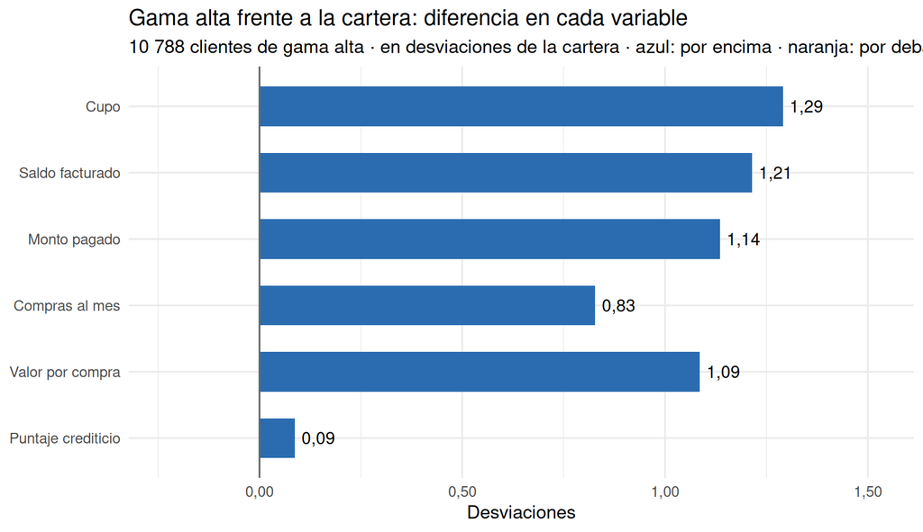

```r
data.frame(variable = factor(etiqueta[vars], levels = rev(etiqueta[vars])), dif = dif1_std) |>
  ggplot(aes(dif, variable, fill = dif > 0)) +
  geom_col(width = 0.6) +
  geom_vline(xintercept = 0, color = "grey40") +
  geom_text(aes(label = coma(dif, 2), hjust = ifelse(dif > 0, -0.2, 1.2)), size = 4.2) +
  scale_fill_manual(values = c("TRUE" = "#2B6CB0", "FALSE" = "#C05621"), guide = "none") +
  scale_x_continuous(expand = expansion(mult = 0.25), labels = function(x) coma(x, 2)) +
  labs(title = "Gama alta frente a la cartera: diferencia en cada variable",
       subtitle = paste0(miles(ng), " clientes de gama alta · en desviaciones de la cartera · ",
                         "azul: por encima · naranja: por debajo (montos en log)"),
       x = "Desviaciones", y = NULL)
```

- 👀 **Qué vemos:** frente al promedio de la cartera, la gama alta queda por encima en cupo, saldo facturado, monto pagado, compras al mes, valor por compra y puntaje crediticio y por debajo en ninguna. La diferencia más grande es la de cupo, a 1,29 desviaciones. En rupias (tabla de arriba), el cupo promedio de la gama alta es 2,9 veces el de la cartera (2 072 148 ₹ frente a 709 677 ₹) y el valor por compra 2,0 veces; el puntaje crediticio, en cambio, apenas se mueve (635 frente a 629 puntos).
- 💼 **Qué significa para el cliente:** es una diferencia de nivel: todas las variables que se apartan van en el mismo sentido (hacia arriba). Pero estas barras no son seis hallazgos independientes: cupo, saldo y pago se relacionan (correlaciones de 0,88 a 0,94), así que una brecha en el cupo casi siempre va acompañada de brechas en las otras dos.
- ✅ **Qué decide el cliente:** no presentar seis barras sueltas al comité; pedir **una sola medida** de cuánto se aleja la gama alta de la cartera.

## 2.2 ¿Es grande? La distancia $D$

```r
h1 <- hotelling_1(Yg, mu)
D1 <- h1[["D"]]
round(D1, 3)
```

```
## [1] 2.952
```

```r
# Un solo número por cliente que resume en qué se parece al grupo: sube cuando el cliente se parece a la gama alta
w1      <- solve(cov(Yg), dif1)
idx_ref <- as.numeric(X %*% w1)
pct_medio1 <- 100 * mean(idx_ref < mean(idx_ref[g1]))

# hotelling_1() mide la distancia con la variación DENTRO de la gama alta. ¿Es esa variación parecida a la de la cartera?
razon_sd <- apply(Yg, 2, sd) / sd_base
D1_cartera <- sqrt(as.numeric(t(dif1) %*% solve(cov(X)) %*% dif1))   # la misma distancia, medida con la variación de toda la cartera
round(setNames(razon_sd, etiqueta[vars]), 2)
```

```
##               Cupo    Saldo facturado       Monto pagado     Compras al mes
##               0.54               0.65               0.69               0.84
##   Valor por compra Puntaje crediticio
##               1.08               1.00
```

```r
c(D_con_la_variacion_de_la_gama_alta = round(D1, 3), D_con_la_variacion_de_la_cartera = round(D1_cartera, 3))
```

```
## D_con_la_variacion_de_la_gama_alta   D_con_la_variacion_de_la_cartera
##                              2.952                              1.306
```

> 📝 **Apunte: qué mide $D$.** Con una sola variable, la distancia es (promedio del grupo − promedio de la referencia) / desviación: cuántas «desviaciones» separan los dos promedios. Con las seis variables se hace lo mismo descontando que se mueven juntas. Una distancia de 1 es una desviación completa (mucho); una de 0,1 casi no se ve. Las palabras que usamos (pequeña < 0,2; moderada < 0,5; grande < 1; muy grande < 2; enorme desde 2) son una convención **nuestra** para hablar con el cliente. Ojo: $D$ compara **promedios**; que el cliente típico esté lejos no dice que cada cliente lo esté (eso es «¿separa?»).
- 👀 **Qué vemos:** el promedio de la gama alta está a 2,95 desviaciones del promedio de la cartera, contando las seis variables al tiempo. Si ordenamos a toda la cartera por el «índice de parecido a la gama alta» (el que mejor la distingue), el cliente promedio de gama alta queda por encima de 90 de cada 100 clientes. La gama alta varía menos que la cartera (en cupo, su desviación es 0,54 veces la de la cartera), y como `hotelling_1()` mide con la variación del grupo, la distancia se ve más grande: medida con la variación de toda la cartera es 1,31.
- 💼 **Qué significa para el cliente:** es una distancia enorme entre promedios: el cliente típico de gama alta queda muy lejos del promedio de la cartera (si eso alcanza para separar a cada cliente se ve más abajo). Aun con la medida más conservadora (1,31, muy grande) la gama alta se aparta con claridad.
- ✅ **Qué decide el cliente:** en el informe dice «la gama alta está entre 1,31 y 2,95 desviaciones de la cartera (muy grande a enorme)», no «es muy distinta» ni «es igual»; falta ver si eso separa a cada cliente.

## 2.3 ¿Es real? ¿O puede ser mala suerte?

Sacamos 1 000 grupos al azar de la propia cartera, del mismo tamaño que la gama alta, y a cada uno le medimos la misma distancia.

```r
set.seed(711)
D_azar <- replicate(1000, {
  g <- X[sample.int(nrow(X), ng), , drop = FALSE]
  d <- colMeans(g) - mu
  sqrt(as.numeric(t(d) %*% solve(cov(g)) %*% d))
})
p1    <- h1[["p"]]
real1 <- p1 < 0.05
round(h1, 3)
```

```
##         n         D        T2         F         p
## 10788.000     2.952 94036.992 15665.567     0.000
```

```r
c(distancia_tipica_por_azar = round(median(D_azar), 3), la_mayor_de_1000 = round(max(D_azar), 3),
  la_de_la_gama_alta = round(D1, 3))
```

```
## distancia_tipica_por_azar          la_mayor_de_1000        la_de_la_gama_alta
##                     0.020                     0.043                     2.952
```

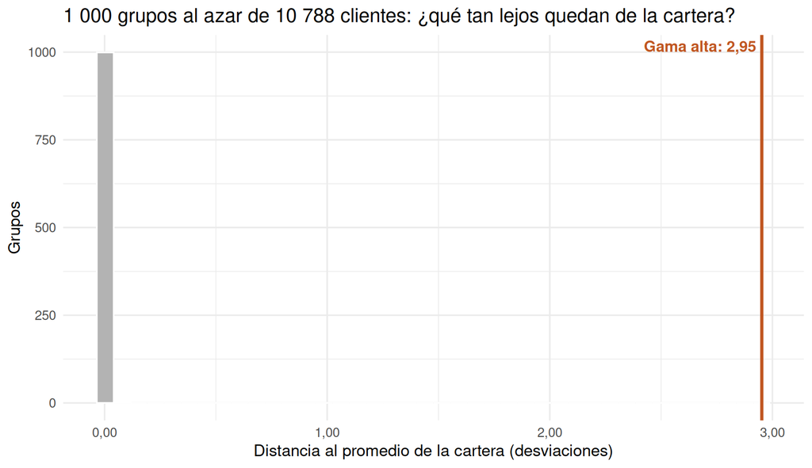

```r
ggplot(data.frame(D = D_azar), aes(D)) +
  geom_histogram(bins = 40, fill = "grey70", color = "white") +
  geom_vline(xintercept = D1, color = "#C05621", linewidth = 1.2) +
  annotate("text", x = D1, y = Inf, vjust = 1.5, hjust = ifelse(D1 > max(D_azar) / 2, 1.05, -0.05),
           color = "#C05621", label = paste0("Gama alta: ", coma(D1, 2)), fontface = "bold", size = 4.3) +
  scale_x_continuous(labels = function(x) coma(x, 2)) +
  labs(title = paste0("1 000 grupos al azar de ", miles(ng), " clientes: ¿qué tan lejos quedan de la cartera?"),
       x = "Distancia al promedio de la cartera (desviaciones)", y = "Grupos")
```

- 👀 **Qué vemos:** un grupo de 10 788 clientes sacado al azar queda típicamente a 0,020 desviaciones; el más lejano de los 1 000 quedó a 0,043. La gama alta está a 2,95. El cálculo exacto (T² de Hotelling, 94 037,0) da que la probabilidad de ver una distancia así por azar es **menos de una en un millón**.
- 💼 **Qué significa para el cliente:** la diferencia es real: la gama alta no se aparta de la cartera por mala suerte del grupo.
- ✅ **Qué decide el cliente:** puede afirmar que la diferencia existe, y debe acompañarla siempre con su tamaño (D) para que nadie la lea como grande por el solo hecho de ser real.

## 2.4 ¿Separa? ¿Cuántos clientes de gama alta caen del otro lado?

Que el promedio esté desplazado no dice que cada cliente lo esté. Usamos el índice de parecido a la gama alta (un número por cliente) y miramos qué parte del grupo queda **por debajo de la mediana de la cartera** (si la gama alta fuera igual a la cartera, serían 50 de cada 100). Y la prueba de fuego: clasificamos a cada cliente como «gama alta» o «resto» con las seis variables y contamos aciertos.

```r
med_ref    <- median(idx_ref)
otro_lado1 <- 100 * mean(idx_ref[g1] < med_ref)
c(clientes_de_gama_alta_del_otro_lado = sum(idx_ref[g1] < med_ref), de_cada_100 = round(otro_lado1, 1))
```

```
## clientes_de_gama_alta_del_otro_lado                         de_cada_100
##                                   0                                   0
```

```r
grp1     <- factor(ifelse(g1, "Gama alta", "Resto"), levels = c("Resto", "Gama alta"))
lda1     <- MASS::lda(as.data.frame(X), grp1)
acierto1 <- 100 * mean(predict(lda1)$class == grp1)
base1    <- 100 * max(table(grp1)) / length(grp1)
sep1     <- veredicto_separa(acierto1, base1)
c(acierto_con_las_seis = round(acierto1, 1), acierto_diciendo_siempre_resto = round(base1, 1))
```

```
##           acierto_con_las_seis acierto_diciendo_siempre_resto
##                           90.5                           78.4
```

```r
# ¿Dónde se equivoca? Tabla de clasificación
conf1 <- table(real = grp1, clasificado_como = predict(lda1)$class)
conf1
```

```
##            clasificado_como
## real        Resto Gama alta
##   Resto     38506       706
##   Gama alta  4033      6755
```

```r
ga_perdidos <- 100 * conf1["Gama alta", "Resto"] / sum(conf1["Gama alta", ])
# El otro lado de la mezcla: clientes del resto con un índice tan alto como el del cliente típico de gama alta
p10_g1      <- quantile(idx_ref[g1], 0.10)
resto_arriba <- 100 * mean(idx_ref[!g1] > p10_g1)
c(gama_alta_clasificados_como_resto_de_cada_100 = round(ga_perdidos, 1),
  resto_por_encima_del_decil_10_de_la_gama_alta_de_cada_100 = round(resto_arriba, 1))
```

```
##             gama_alta_clasificados_como_resto_de_cada_100
##                                                      37.4
## resto_por_encima_del_decil_10_de_la_gama_alta_de_cada_100
##                                                       6.7
```

```r
# Casos concretos: el cliente de gama alta con el índice más bajo, y uno del resto con índice igual al típico de gama alta
ficha1 <- function(ix) data.frame(
  cliente = datos$id_cliente[ix], tarjeta = datos$Card_Type[ix], cupo = miles(datos$Credit_Limit[ix]),
  saldo = miles(datos$Statement_Balance[ix]), pagado = miles(datos$Payment_Amount[ix]),
  compras_al_mes = round(datos$Monthly_Transactions[ix], 1), valor_por_compra = miles(datos$Avg_Transaction_Value[ix]),
  puntaje = round(datos$Credit_Score[ix]),
  de_cada_100_de_la_cartera_con_indice_mayor = round(sapply(ix, function(i) 100 * mean(idx_ref > idx_ref[i])), 1))
ord1  <- which(g1)[order(idx_ref[g1])][1]
i_res <- which(!g1)[which.min(abs(idx_ref[!g1] - median(idx_ref[g1])))]
ficha1(c(ord1, i_res))
```

| cliente | tarjeta | cupo | saldo | pagado | compras_al_mes | valor_por_compra | puntaje | de_cada_100_de_la_cartera_con_indice_mayor |
| --- | --- | --- | --- | --- | --- | --- | --- | --- |
| CC109918 | Platinum | 812 000 | 583 140 | 553 983 | 63 | 2 007 | 658 | 49.6 |
| CC133121 | Gold | 729 000 | 261 458 | 240 541 | 109 | 416 | 670 | 11.1 |

```r
mediana_cartera <- sapply(datos[vars], median)
round(setNames(mediana_cartera, etiqueta[vars]), 1)
```

```
##               Cupo    Saldo facturado       Monto pagado     Compras al mes
##           396000.0           192358.4           136639.8               76.0
##   Valor por compra Puntaje crediticio
##              617.2              638.0
```

- 👀 **Qué vemos:** 0 clientes de gama alta (0,0 de cada 100) quedan por debajo de la mediana de la cartera en el índice (en el Atlántico eran 31,5 por encima). Pero eso solo dice que la gama alta está en la mitad de arriba, donde también vive la mitad del resto. Con las seis variables se acierta si un cliente es de gama alta o del resto en 90,5 de cada 100, cuando diciendo siempre «resto» se acierta en 78,4; el error se concentra en la gama alta: 37 de cada 100 de sus clientes quedan clasificados como «resto». Los dos casos de la tabla lo muestran: el cliente CC109918 tiene tarjeta Platinum y un cupo de 812 000 ₹ (mediana de la cartera: 396 000 ₹), y su índice es más bajo que el de 49,6 de cada 100 clientes de la cartera: está en la mitad, con ficha de cliente corriente; el cliente CC133121 tiene tarjeta Gold (no es de gama alta), pero su ficha es la del cliente típico de gama alta, con un cupo de 729 000 ₹.
- 💼 **Qué significa para el cliente:** la gama alta se separa en parte del resto: sus clientes están en la mitad alta de la cartera, pero ahí se cruzan con clientes del resto que tienen la misma ficha (6,7 de cada 100 clientes del resto superan al 10 por ciento más bajo de la gama alta, y como el resto es mucho más numeroso, esa zona común pesa). Por eso la distancia enorme entre promedios no se traduce en grupos que no se tocan.
- ✅ **Qué decide el cliente:** puede usar reglas de segmento, revisando caso a caso a los que quedan en la zona común.

# 3 Dos muestras: ¿los jóvenes y los mayores son distintos?

Ahora comparamos dos grupos entre sí: los **jóvenes** (hasta 29 años) y los **mayores** (desde 40 años).

## 3.1 Variable por variable: ¿nivel o perfil?

```r
A <- X[joven, , drop = FALSE]; B <- X[mayor, , drop = FALSE]
n_a <- nrow(A); n_b <- nrow(B)
Sp  <- ((n_a - 1) * cov(A) + (n_b - 1) * cov(B)) / (n_a + n_b - 2)
dif2     <- colMeans(A) - colMeans(B)
dif2_std <- dif2 / sqrt(diag(Sp))            # en desviaciones de los clientes

orig2 <- rbind(jovenes = colMeans(datos[joven, vars]), mayores = colMeans(datos[mayor, vars]))
colnames(orig2) <- etiqueta[vars]
round(orig2, 1)
```

```
##             Cupo Saldo facturado Monto pagado Compras al mes Valor por compra
## jovenes 718093.7        369132.0     281909.1           83.4            838.1
## mayores 701424.7        362863.1     275223.5           82.8            835.2
##         Puntaje crediticio
## jovenes              629.2
## mayores              629.1
```

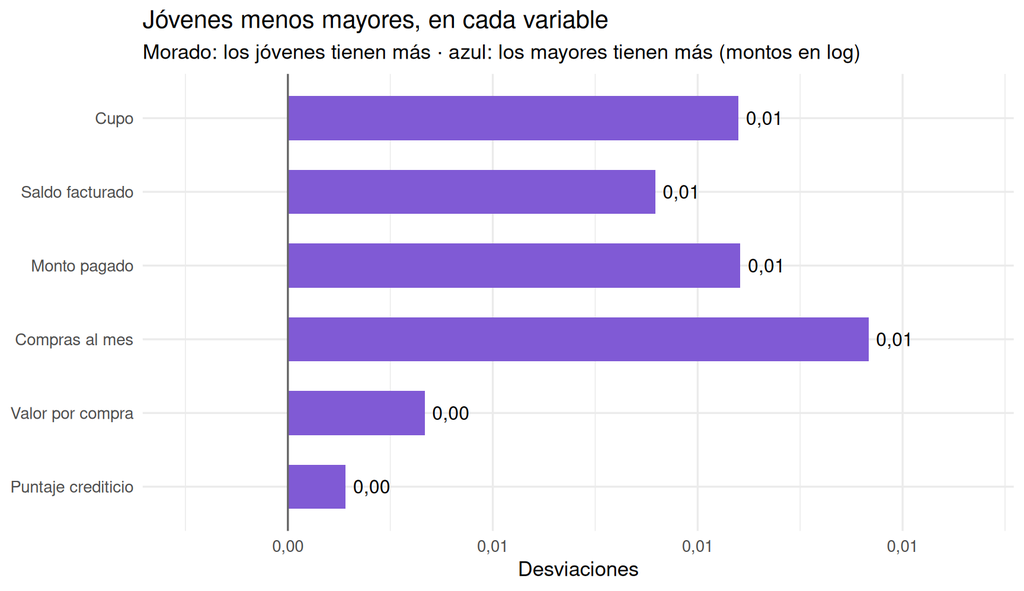

```r
data.frame(variable = factor(etiqueta[vars], levels = rev(etiqueta[vars])), dif = dif2_std) |>
  ggplot(aes(dif, variable, fill = dif > 0)) +
  geom_col(width = 0.6) +
  geom_vline(xintercept = 0, color = "grey40") +
  geom_text(aes(label = coma(dif, 2), hjust = ifelse(dif > 0, -0.2, 1.2)), size = 4.2) +
  scale_fill_manual(values = c("TRUE" = "#805AD5", "FALSE" = "#2B6CB0"), guide = "none") +
  scale_x_continuous(expand = expansion(mult = 0.25), labels = function(x) coma(x, 2)) +
  labs(title = "Jóvenes menos mayores, en cada variable",
       subtitle = "Morado: los jóvenes tienen más · azul: los mayores tienen más (montos en log)",
       x = "Desviaciones", y = NULL)
```

- 👀 **Qué vemos:** ninguna de las seis variables se aparta más de 0,05 desviaciones entre jóvenes y mayores; la diferencia más grande es la de compras al mes, de apenas 0,01 desviaciones (jóvenes menos mayores). En unidades originales (tabla de arriba) pasa lo mismo: el cupo promedio es de 718 094 ₹ en los jóvenes y 701 425 ₹ en los mayores, y el puntaje de 629,2 frente a 629,1.
- 💼 **Qué significa para el cliente:** no es una diferencia de **nivel** (no todo sube en un grupo) ni de **perfil** (no hay variables que suban en uno y bajen en el otro): en las seis variables los jóvenes y los mayores tienen, en promedio, la misma ficha.
- ✅ **Qué decide el cliente:** no tiene, a simple vista, una razón para diseñar campañas distintas por edad; falta comprobar con una sola medida que las seis diferencias juntas tampoco suman algo.

## 3.2 ¿Qué tan lejos y qué tan real? Distancia $D$ y comprobación con `manova()`

```r
h2 <- hotelling_2(A, B)
D2 <- h2[["D"]]; p2 <- h2[["p"]]; real2 <- p2 < 0.05
signif(h2, 4)
```

```
##      D     T2      F      p
## 0.0259 5.8910 0.9818 0.4356
```

```r
# Comprobación: R lo calcula con manova(); debe dar el mismo T²
XY <- rbind(A, B)
gr <- factor(rep(c("Jóvenes", "Mayores"), c(n_a, n_b)))
L  <- summary(manova(XY ~ gr), test = "Wilks")$stats[1, 2]
T2_manova <- (nrow(XY) - 2) * (1 / L - 1)
round(c(T2_hotelling = h2[["T2"]], T2_manova = T2_manova), 2)
```

```
## T2_hotelling    T2_manova
##         5.89         5.89
```

- 👀 **Qué vemos:** los dos grupos están a 0,03 desviaciones; la probabilidad de que sea azar es **alrededor de 44 de cada 100**. El T² de Hotelling (5,89) coincide con el que da `manova()` (5,89).
- 💼 **Qué significa para el cliente:** no se puede descartar el azar y es una distancia pequeña: el joven típico se parece al mayor típico mucho más de lo que se diferencia.
- ✅ **Qué decide el cliente:** no debe hablar de perfiles distintos por edad con estas variables.

## 3.3 Dos clientes con un resultado parecido y perfiles opuestos

```r
Z      <- scale(X)
nivel  <- rowMeans(Z)
a_var  <- names(which.max(dif2_std)); b_var <- names(which.min(dif2_std))
brecha <- Z[, a_var] - Z[, b_var]

cerca <- abs(nivel) <= 0.25
i_j <- which(joven & cerca)[which.max(brecha[joven & cerca])]
i_m <- NA
for (tol in c(0.05, 0.10, 0.20)) {
  cand <- which(mayor & abs(nivel - nivel[i_j]) <= tol)
  if (length(cand) > 0) { i_m <- cand[which.min(brecha[cand])]; break }
}

ficha2 <- function(ix, rotulo) data.frame(
  caso = rotulo, cliente = datos$id_cliente[ix], edad = datos$Age[ix],
  cupo = miles(datos$Credit_Limit[ix]), saldo = miles(datos$Statement_Balance[ix]),
  pagado = miles(datos$Payment_Amount[ix]), compras_al_mes = round(datos$Monthly_Transactions[ix], 1),
  valor_por_compra = miles(datos$Avg_Transaction_Value[ix]), puntaje = round(datos$Credit_Score[ix]),
  indice_general = round(nivel[ix], 2))
rbind(ficha2(i_j, "Joven"), ficha2(i_m, "Mayor"))
```

|  | caso | cliente | edad | cupo | saldo | pagado | compras_al_mes | valor_por_compra | puntaje | indice_general |
| --- | --- | --- | --- | --- | --- | --- | --- | --- | --- | --- |
| 19445 | Joven | CC119444 | 28 | 699 000 | 684 339 | 75 277 | 168 | 557 | 401 | -0.06 |
| 34522 | Mayor | CC134521 | 50 | 256 000 | 75 882 | 73 605 | 27 | 1 069 | 734 | -0.09 |

```r
c(joven_en_a = round(Z[i_j, a_var], 2), joven_en_b = round(Z[i_j, b_var], 2),
  mayor_en_a = round(Z[i_m, a_var], 2), mayor_en_b = round(Z[i_m, b_var], 2))
```

```
## joven_en_a joven_en_b mayor_en_a mayor_en_b
##       2.02      -3.33      -1.33       1.53
```

- 👀 **Qué vemos:** el cliente CC119444 (joven, 28 años) y el CC134521 (mayor, 50 años) tienen el mismo índice general (-0,06 y -0,09). En compras al mes el joven está en 2,02 y el mayor en -1,33; en puntaje crediticio, el joven en -3,33 y el mayor en 1,53 (desviaciones frente a toda la cartera).
- 💼 **Qué significa para el cliente:** dos clientes que un resumen único vería como iguales tienen fichas opuestas y necesitan cosas distintas. Es el caso extremo, escogido a propósito: no dice cómo son la mayoría de los jóvenes y de los mayores, y en promedio los dos grupos son iguales; podría haberse encontrado la misma pareja con el joven y el mayor intercambiados.
- ✅ **Qué decide el cliente:** el seguimiento no se diseña con un índice general; se diseña con el perfil, y cada cliente se mira por su propia ficha.

## 3.4 ¿Separa? El acierto al clasificar, contra adivinar

```r
datos_lda <- data.frame(XY, grupo = gr)
lda2      <- MASS::lda(grupo ~ ., data = datos_lda)
acierto2  <- 100 * mean(predict(lda2)$class == gr)
acierto2_cv <- 100 * mean(MASS::lda(grupo ~ ., data = datos_lda, CV = TRUE)$class == gr)   # sin «hacer trampa»
base2     <- 100 * max(table(gr)) / length(gr)
sep2      <- veredicto_separa(acierto2, base2)
c(acierto_con_las_seis = round(acierto2, 1), acierto_validacion_cruzada = round(acierto2_cv, 1),
  acierto_diciendo_siempre_el_grupo_mas_grande = round(base2, 1))
```

```
##                         acierto_con_las_seis
##                                         50.4
##                   acierto_validacion_cruzada
##                                         49.9
## acierto_diciendo_siempre_el_grupo_mas_grande
##                                         50.2
```

- 👀 **Qué vemos:** con las seis variables se acierta si un cliente es joven o mayor en 50,4 de cada 100 (49,9 con validación cruzada), cuando diciendo siempre el grupo más grande («Mayores») se acierta en 50,2: las seis variables mejoran el acierto en 0,2 puntos.
- 💼 **Qué significa para el cliente:** conocer las seis variables de un cliente no ayuda a saber si es joven o mayor: es lo mismo que lanzar una moneda. Cuadra con lo anterior: la diferencia no es real y los dos grupos se montan por completo.
- ✅ **Qué decide el cliente:** no diseña campañas distintas por edad a partir de estas variables: el contenido de las campañas se define por el comportamiento de cada cliente (cupo, saldo, pago, uso y puntaje), no por su edad.

# 4 ¿Qué viaja con el grupo? La gama alta y las compras internacionales

> 📝 **Apunte:** una variable «viaja con el grupo» cuando el grupo no es una muestra al azar de la cartera en esa variable. Entonces parte de la diferencia puede deberse a esa variable y no al grupo: es el caso del estrato con el Atlántico en las notas. Buscamos entre las variables que **no** entraron a la distancia y comparamos **clientes parecidos** en la que más viaja.

```r
W <- datos[candidatas]
for (v in candidatas) if (abs(skew(W[[v]])) > 1) W[[v]] <- log1p(W[[v]])
d_cand <- sapply(candidatas, function(v) (mean(W[[v]][g1]) - mean(W[[v]])) / sd(W[[v]]))
viaja  <- candidatas[which.max(abs(d_cand))]
data.frame(variable = etiqueta[candidatas], gama_alta_menos_cartera_en_desviaciones = round(d_cand, 2),
           row.names = NULL) |> arrange(desc(abs(gama_alta_menos_cartera_en_desviaciones)))
```

| variable | gama_alta_menos_cartera_en_desviaciones |
| --- | --- |
| Compras internacionales | 1.47 |
| Ingreso anual | 1.21 |
| Compras a cuotas | 0.76 |
| Edad | -0.02 |

- 👀 **Qué vemos:** de las variables que quedaron fuera de la distancia, la que más se aparta en la gama alta es **compras internacionales**, a 1,47 desviaciones de la cartera; la que menos, la edad (-0,02).
- 💼 **Qué significa para el cliente:** la gama alta no es una muestra al azar de la cartera en compras internacionales: quien tiene tarjeta de gama alta suele tener también más de eso, así que parte de su diferencia puede ir con esa variable. Ojo: a diferencia del estrato en las notas, compras internacionales es un comportamiento con la tarjeta, no algo que el cliente traía antes; con estos datos no se sabe si va con el tipo de tarjeta o con quién la pide.
- ✅ **Qué decide el cliente:** antes de armar una política «para la gama alta», revisa si la diferencia sigue entre clientes parecidos en compras internacionales.

Dividimos a toda la cartera en niveles de compras internacionales (tercios cuando la variable lo permite; si muchos clientes tienen el mismo valor, quedan menos niveles) y comparamos a la gama alta con la cartera **dentro del mismo nivel**:

```r
x_v <- W[[viaja]]
if (length(unique(x_v)) <= 6) {
  estr <- factor(x_v)
} else {
  br   <- unique(quantile(x_v, c(0, 1/3, 2/3, 1)))
  estr <- cut(x_v, br, include.lowest = TRUE, dig.lab = 6)
  levels(estr) <- if (nlevels(estr) == 3) c("bajo", "medio", "alto") else if (nlevels(estr) == 2) c("bajo", "alto") else levels(estr)
}
niv <- levels(estr)

por_nivel <- lapply(niv, function(k) {
  en  <- estr == k
  Yk  <- X[g1 & en, , drop = FALSE]; nk <- nrow(Yk)
  mu_k <- colMeans(X[en, , drop = FALSE])
  dk  <- if (nk > 0) colMeans(Yk) - mu_k else rep(0, n_var)
  hk  <- if (nk > 5 * n_var) hotelling_1(Yk, mu_k) else c(n = nk, D = NA, T2 = NA, F = NA, p = NA)
  list(n = nk, de_el_grupo = 100 * nk / ng, de_la_cartera = 100 * mean(en), dk = dk, D = hk[["D"]], p = hk[["p"]],
       rango = paste(coma(min(datos[[viaja]][en]), 0), "a", coma(max(datos[[viaja]][en]), 0)))
})

# Diferencia «ajustada»: el promedio de las diferencias dentro de cada nivel, ponderado por cuántos clientes del grupo hay en él
dif_adj     <- Reduce(`+`, lapply(por_nivel, function(r) r$n / ng * r$dk))
dif_adj_std <- dif_adj / sd_base
D_adj       <- sqrt(as.numeric(t(dif_adj) %*% solve(cov(Yg)) %*% dif_adj))

data.frame(nivel = niv, rango_de_la_variable = sapply(por_nivel, `[[`, "rango"),
           clientes_de_gama_alta = sapply(por_nivel, `[[`, "n"),
           de_cada_100_de_la_gama_alta = round(sapply(por_nivel, `[[`, "de_el_grupo"), 1),
           de_cada_100_de_la_cartera = round(sapply(por_nivel, `[[`, "de_la_cartera"), 1),
           D_dentro_del_nivel = round(sapply(por_nivel, `[[`, "D"), 2),
           probabilidad_de_azar = sapply(por_nivel, function(r) una_en(r$p)))
```

| nivel | rango_de_la_variable | clientes_de_gama_alta | de_cada_100_de_la_gama_alta | de_cada_100_de_la_cartera | D_dentro_del_nivel | probabilidad_de_azar |
| --- | --- | --- | --- | --- | --- | --- |
| bajo | 0 a 1 | 1006 | 9.3 | 69.8 | 4.70 | menos de una en un millón |
| alto | 2 a 14 | 9782 | 90.7 | 30.2 | 0.86 | menos de una en un millón |

```r
c(D_sin_ajustar = round(D1, 3), D_entre_clientes_parecidos = round(D_adj, 3))
```

```
##              D_sin_ajustar D_entre_clientes_parecidos
##                      2.952                      1.115
```

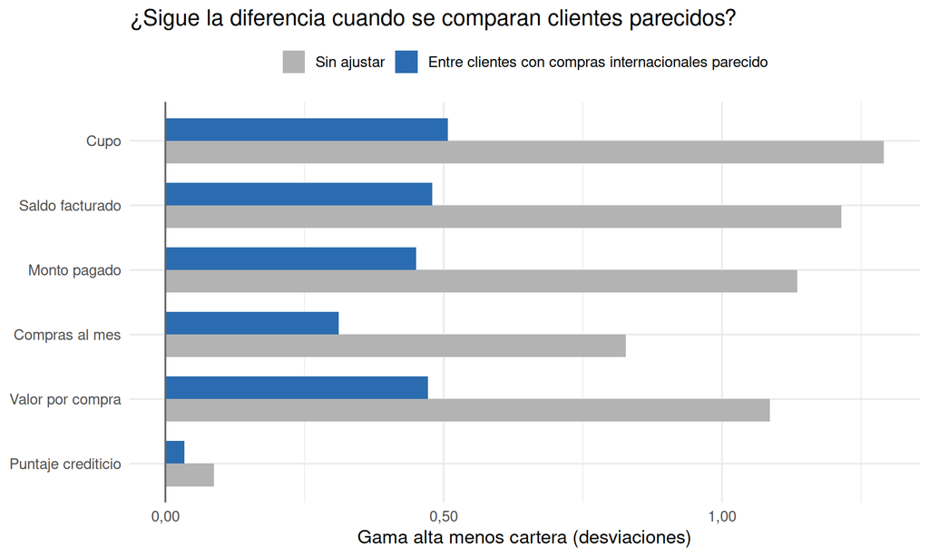

```r
lab_adj <- paste0("Entre clientes con ", tolower(etiqueta[viaja]), " parecido")
largo4 <- rbind(data.frame(variable = etiqueta[vars], dif = dif1_std,    comparacion = "Sin ajustar"),
                data.frame(variable = etiqueta[vars], dif = dif_adj_std, comparacion = lab_adj))
largo4$variable    <- factor(largo4$variable, levels = rev(etiqueta[vars]))
largo4$comparacion <- factor(largo4$comparacion, levels = c("Sin ajustar", lab_adj))
ggplot(largo4, aes(dif, variable, fill = comparacion)) +
  geom_col(position = "dodge", width = 0.7) +
  geom_vline(xintercept = 0, color = "grey40") +
  scale_fill_manual(values = c("grey70", "#2B6CB0"), name = NULL) +
  scale_x_continuous(labels = function(x) coma(x, 2)) +
  labs(title = "¿Sigue la diferencia cuando se comparan clientes parecidos?",
       x = "Gama alta menos cartera (desviaciones)", y = NULL) +
  theme(legend.position = "top")
```

- 👀 **Qué vemos:** en el nivel más alto de compras internacionales está el 91 de cada 100 de la gama alta y el 30 de la cartera. Al comparar dentro del mismo nivel, la distancia pasa de 2,95 a 1,11 desviaciones.
- 💼 **Qué significa para el cliente:** **parte** de la diferencia viaja con compras internacionales (la distancia baja de 2,95 a 1,11, 62 de cada 100 menos), pero no toda. Esto no demuestra que compras internacionales sea la causa: solo que la gama alta y esa variable aparecen juntas.
- ✅ **Qué decide el cliente:** no puede atribuir la diferencia solo a la tarjeta ni solo a compras internacionales: una política para la gama alta debe revisar las dos cosas.

# 5 Las tres preguntas y la decisión

```r
# La regla de comparación de las notas: iris, dos especies que no se tocan
ir <- droplevels(iris[iris$Species != "virginica", ])
h_iris <- hotelling_2(as.matrix(ir[ir$Species == "versicolor", 1:4]), as.matrix(ir[ir$Species == "setosa", 1:4]))
acierto_iris <- 100 * mean(predict(MASS::lda(ir[1:4], ir$Species))$class == ir$Species)

celda_real  <- function(p) paste0(ifelse(p < 0.05, "sí", "no"), " · azar: ", una_en(p))
celda_D     <- function(D) paste0(coma(D, 2), " · ", tam_D(D))
celda_sep   <- function(a, b) paste0(veredicto_separa(a, b), " · acierta ", coma(a, 0), " de cada 100; adivinando, ", coma(b, 0))

data.frame(
  `Comparación` = c("Gama alta frente a la cartera (una muestra)", "Jóvenes frente a mayores (dos muestras)",
                    "Setosa frente a versicolor (iris, referencia)"),
  `¿Es real?`  = c(celda_real(p1), celda_real(p2), celda_real(h_iris[["p"]])),
  `¿Es grande? (D)` = c(celda_D(D1), celda_D(D2), celda_D(h_iris[["D"]])),
  `¿Separa?`   = c(celda_sep(acierto1, base1), celda_sep(acierto2, base2), celda_sep(acierto_iris, 50)),
  check.names = FALSE)
```

| Comparación | ¿Es real? | ¿Es grande? (D) | ¿Separa? |
| --- | --- | --- | --- |
| Gama alta frente a la cartera (una muestra) | sí · azar: menos de una en un millón | 2,95 · enorme | en parte · acierta 91 de cada 100; adivinando, 78 |
| Jóvenes frente a mayores (dos muestras) | no · azar: alrededor de 44 de cada 100 | 0,03 · pequeña | no · acierta 50 de cada 100; adivinando, 50 |
| Setosa frente a versicolor (iris, referencia) | sí · azar: menos de una en un millón | 10,16 · enorme | sí · acierta 100 de cada 100; adivinando, 50 |

**Decisión para el cliente.**

> La gama alta está a 2,95 desviaciones de la cartera (enorme; 1,31 medida con la variación de toda la cartera) y los jóvenes a 0,03 de los mayores (pequeña); la referencia de una diferencia que sí separa es la de iris, a 10,2 desviaciones y con 100 de cada 100 aciertos. **Gama alta:** la gama alta se separa en parte del resto: justifica reglas de segmento propias (alertas y aumentos de cupo), revisando caso a caso a los de la zona común. Parte de la diferencia viaja con compras internacionales (comparando clientes parecidos la distancia baja de 2,95 a 1,11), así que la política debe mirar las dos cosas. **Edad:** no hay evidencia de perfiles distintos por edad: no se justifica diseñar campañas separadas. En el informe al comité no basta con decir que las diferencias son «significativas»: van siempre las tres respuestas (¿es real?, ¿es grande?, ¿separa?) y lo que se decide con ellas.

### Qué no sabemos todavía

- **No sabemos por qué.** Todo lo que vemos son grupos que se comportan distinto. No decimos que tener tarjeta de gama alta, o tener cierta edad, cause un cupo, un pago o un puntaje: que algo viaje con el grupo no es que lo cause.
- **La referencia sale de esta misma base.** El promedio de la cartera no es una meta del banco ni una cifra publicada, y el grupo hace parte de él; la base es sintética y sus conclusiones hablan de ella, no de todas las carteras de tarjetas.
- **Los umbrales son nuestros.** Llamar «moderada» a una distancia entre 0,2 y 0,5, o decir que «separa» cuando se acierta en 85 de cada 100 y se mejora en 20 puntos el adivinar, es una convención para hablar con el cliente, no un resultado de la estadística.
- **El acierto no es mora.** Clasificar a un cliente por su ficha dice si se parece a un grupo, no si va a pagar; la base no trae una variable de incumplimiento con la cual verificarlo.
- **La edad es delicada.** Aquí se usa para diseñar mensajes y prever demanda; si la política interna o la regulación del banco permiten usarla para decidirle condiciones a un cliente es algo que la Gerencia debe verificar, y esta comparación no lo respalda.
- **Los grupos de edad dejaron fuera a un tercio de la cartera** (los de edad intermedia) y los montos entran en logaritmo; con otros cortes o sin el logaritmo, las distancias cambiarían de tamaño.